#### Assignment 4: Recommendations

This assign focuses on recommendations using generated data. The following code generates a set of 20 users and a set of 20 user-items:

```r
library(recommenderlab, quietly = TRUE)
set.seed(1)
m <- matrix(sample(c(as.numeric(1:5), NA), 400,
                   replace=TRUE, prob=c(0.05, 0.1, 0.15, 0.1, 0.05, 0.55)),
                   ncol=20,
                   dimnames=list(user=paste("u", 1:20, sep = ""),
                                 item=paste("i", 1:20, sep = "")))
head(m)
```

```
##     item
## user i1 i2 i3 i4 i5 i6 i7 i8 i9 i10 i11 i12 i13 i14 i15 i16 i17 i18 i19
##   u1 NA  5  2  5 NA  3  1  3 NA  NA  NA  NA  NA  NA  NA   3   3   1  NA
##   u2 NA NA  3 NA  4 NA NA  3  2  NA  NA  NA   3  NA  NA  NA  NA  NA  NA
##   u3  3  3  4 NA NA NA NA NA NA   2  NA  NA   5  NA   2  NA  NA  NA   2
##   u4  5 NA  3 NA NA  1 NA NA  4  NA  NA  NA  NA   4  NA  NA   1  NA  NA
##   u5 NA NA NA  3  4  3  4  4  2   2  NA   5  NA   4  NA  NA   2   3   3
##   u6  2 NA  4 NA NA NA NA NA NA  NA  NA  NA  NA  NA  NA   1   1  NA   2
##     item
## user i20
##   u1  NA
##   u2   3
##   u3   3
##   u4   1
##   u5  NA
##   u6  NA
```

```r
# The rating matrix can be written externally as a CSV file.
# write.csv(m, "m.csv")
# m.df <- read.csv("m.csv", header = TRUE, row.names = 1)
# head(as.matrix(m.df))

r <- as(m, "realRatingMatrix")
```

1 Create a normalized rating matrix, `r_z`, using $Z$-scores. Inspect the raw rating and Z-normalized ratings using `image()`.

```r
## Creating Z-score normalized rating matrix and inspecting with raw ratings.

head(as(r,"dgCMatrix"))
```

```
## 6 x 20 sparse Matrix of class "dgCMatrix"
```

```
##    [[ suppressing 20 column names 'i1', 'i2', 'i3' ... ]]
```

```
##
## u1 . 5 2 5 . 3 1 3 . . . . . . . 3 3 1 . .
## u2 . . 3 . 4 . . 3 2 . . . 3 . . . . . . 3
## u3 3 3 4 . . . . . . 2 . . 5 . 2 . . . 2 3
## u4 5 . 3 . . 1 . . 4 . . . . 4 . . 1 . . 1
## u5 . . . 3 4 3 4 4 2 2 . 5 . 4 . . 2 3 3 .
## u6 2 . 4 . . . . . . . . . . . . 1 1 . 2 .
```

```r
identical(as(r, "matrix"),m)
```

```
## [1] TRUE
```

```r
as(r, "list")
```

```
## $u1
##  i2  i3  i4  i6  i7  i8 i16 i17 i18
##   5   2   5   3   1   3   3   3   1
##
## $u2
##  i3  i5  i8  i9 i13 i20
##   3   4   3   2   3   3
##
## $u3
##  i1  i2  i3 i10 i13 i15 i19 i20
##   3   3   4   2   5   2   2   3
##
## $u4
##  i1  i3  i6  i9 i14 i17 i20
##   5   3   1   4   4   1   1
##
## $u5
##  i4  i5  i6  i7  i8  i9 i10 i12 i14 i17 i18 i19
##   3   4   3   4   4   2   2   5   4   2   3   3
##
## $u6
##  i1  i3 i16 i17 i19
##   2   4   1   1   2
##
## $u7
##  i1  i5 i10 i11 i17 i20
##   5   4   4   3   2   4
##
## $u8
##  i1  i4  i8 i10 i14 i16 i17 i19 i20
##   3   4   4   4   4   2   4   4   2
##
## $u9
##  i1  i2  i3  i6  i9 i10 i14 i19
##   3   2   4   5   4   5   3   3
##
## $u10
##  i3  i4  i6  i7  i8 i11 i12 i13 i17 i18 i20
##   3   2   3   3   2   4   2   5   4   4   1
##
```

[output cut: 24 more lines]

```
## $u17
##  i1  i2  i4  i6  i7  i9 i11 i12 i18 i20
##   4   4   2   4   3   3   3   3   2   3
##
## $u18
##  i1  i9 i10 i11 i12 i19
##   1   4   2   1   3   2
##
## $u19
##  i2  i3  i4  i5  i7  i9 i11 i16 i17 i18
##   4   3   4   2   1   3   1   1   3   2
##
## $u20
##  i1  i4  i5  i6  i9 i10 i13 i14 i15 i16 i17
##   4   1   3   3   5   4   5   4   5   3   1
```

```r
head(as(r, "data.frame"))
```

```
##    user item rating
## 12   u1   i2      5
## 20   u1   i3      2
## 29   u1   i4      5
## 47   u1   i6      3
## 56   u1   i7      1
## 65   u1   i8      3
```

```r
#Z-score ratings.
r_z <- normalize(r, method="Z-score")
r_z
```

```
## 20 x 20 rating matrix of class 'realRatingMatrix' with 165 ratings.
## Normalized using Z-score on rows.
```

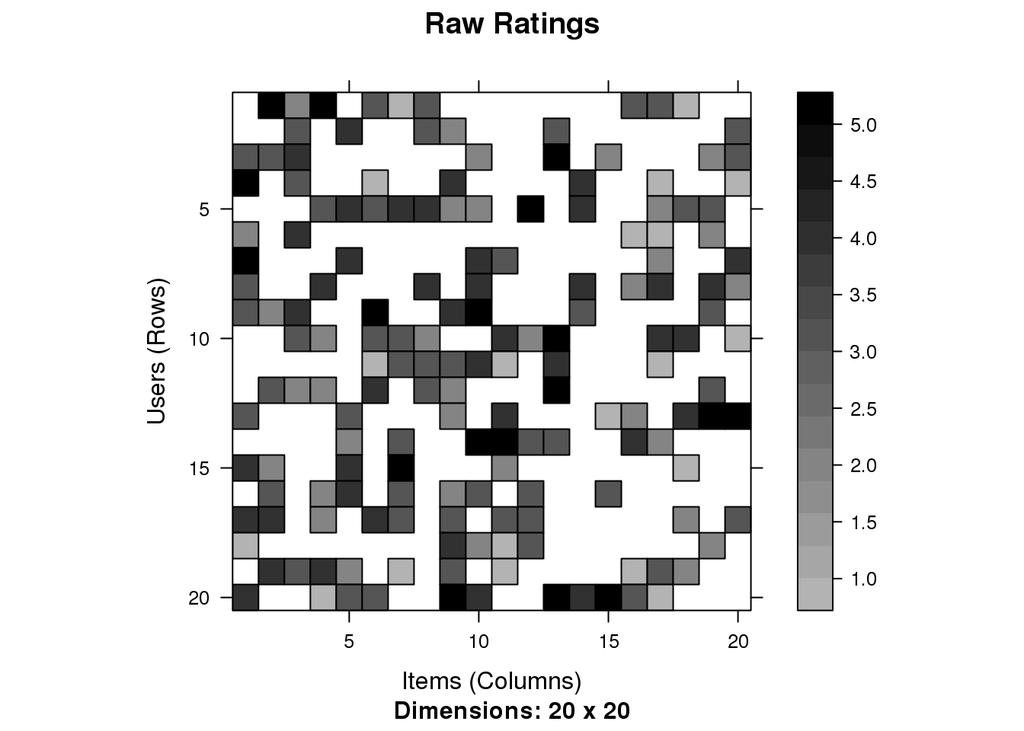

```r
#using image() to do visual inspection.

image(r, main = "Raw Ratings")
```

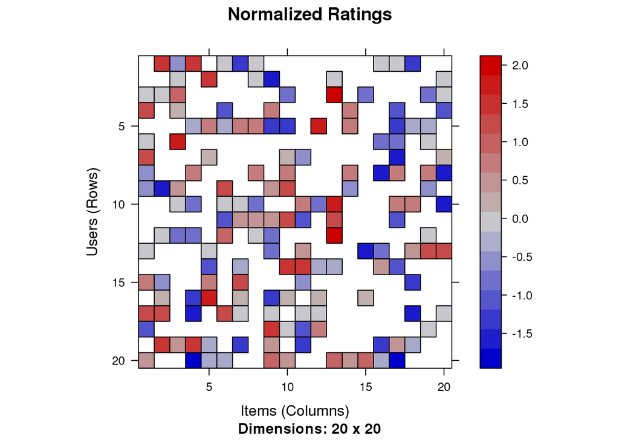

```r
image(r_z, main = "Normalized Ratings")
```

2 Plot the raw and Z-score normalized rating.

```r
## Raw and Normalized Z-score ratings plot.
data(Jester5k)
Jester5k
```

```
## 5000 x 100 rating matrix of class 'realRatingMatrix' with 362106 ratings.
```

```r
r <- sample(Jester5k, 1000)
r
```

```
## 1000 x 100 rating matrix of class 'realRatingMatrix' with 71665 ratings.
```

```r
rowCounts(r[1,])
```

```
## u17654
##     74
```

```r
as(r[1,], "list")
```

```
## $u17654
##    j1    j2    j3    j4    j5    j6    j7    j8    j9   j10   j11   j12
## -0.39 -0.39 -0.39 -0.39 -1.31 -0.39 -1.31 -1.31 -0.39 -0.39 -0.39 -0.39
##   j13   j14   j15   j16   j17   j18   j19   j20   j21   j22   j23   j24
## -1.31 -0.39 -1.31 -1.31 -5.15 -1.31 -1.31 -1.31 -0.39 -0.39 -0.39 -0.39
##   j25   j26   j27   j28   j29   j30   j31   j32   j33   j34   j35   j36
## -0.39 -0.39 -0.39 -0.39  0.78 -0.39 -0.39 -0.87 -0.39 -0.39 -0.39 -0.24
##   j37   j38   j39   j40   j41   j42   j43   j44   j45   j46   j47   j48
## -0.39 -0.39 -0.39 -0.39 -0.39 -0.39 -1.31 -0.39 -0.39 -0.39 -1.31 -0.39
##   j49   j50   j51   j52   j53   j54   j55   j56   j57   j58   j59   j60
## -0.39 -2.14 -0.39 -0.39 -0.92 -1.75 -0.39 -0.39 -0.39 -0.39 -0.39 -0.39
##   j61   j62   j63   j64   j65   j66   j67   j68   j69   j70   j84   j89
## -0.39 -1.36 -0.39 -0.39 -0.39 -0.39 -0.39  0.39 -0.39 -0.39 -1.31 -1.31
##   j98  j100
## -1.31 -0.44
```

```r
rowMeans(r[1,])
```

```
##  u17654
## -0.6695
```

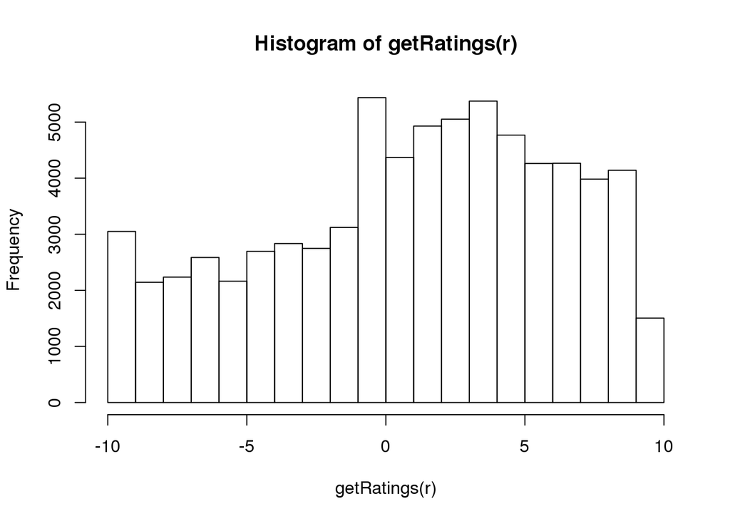

```r
hist(getRatings(r)) #The figure shoes an interesting distribution where all negative values occur with a almost identical frequency and the positive ratings more frequent with a steady decline towards the rating 10, this distribution can be the result of users with strong rating bias.
```

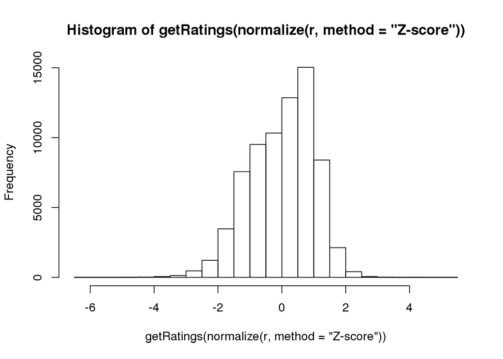

```r
hist(getRatings(normalize(r, method="Z-score"))) #The distribution of ratings are closer to a normal distribution after Z-score normalization and have reduced variance.
```

3 Plot the raw user counts and raw item means. Discuss.

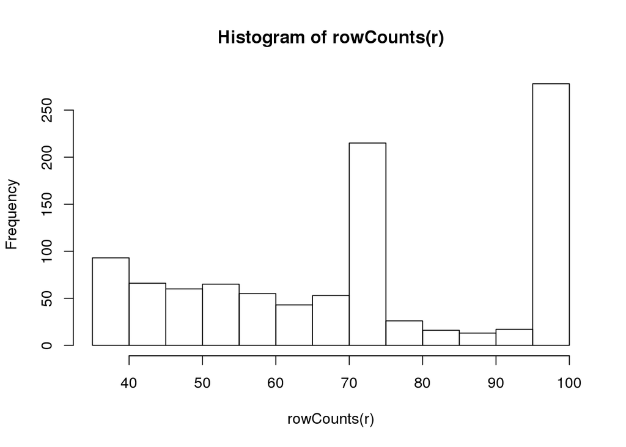

```r
## Computing raw user counts and raw item means.

hist(rowCounts(r)) #user counts.
```

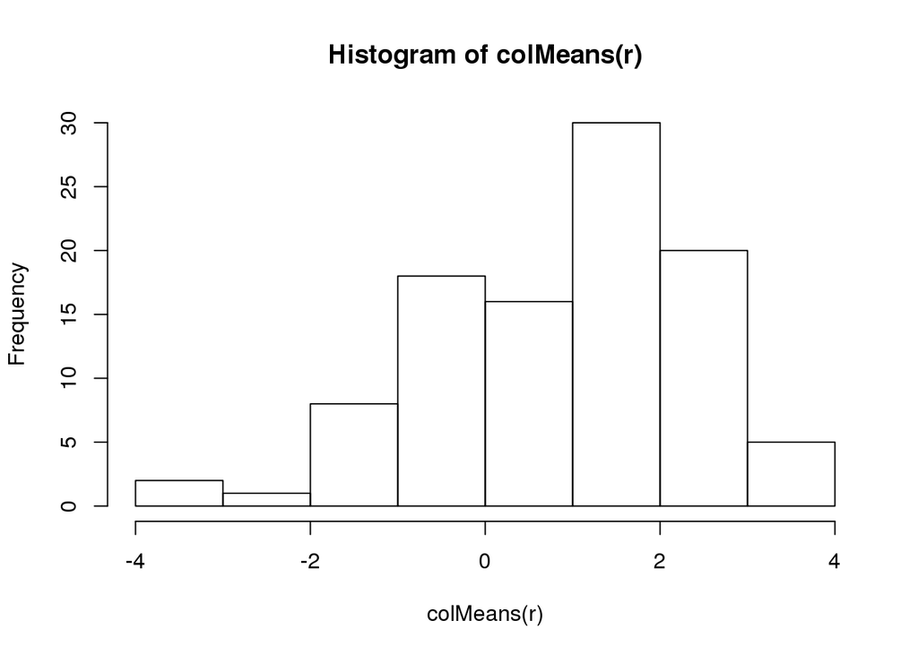

```r
hist(colMeans(r)) #raw item means.
```

4 Create a recommender based on the popularity of items for the first 15 users using the raw ratings.

```r
## Creating a recommender.

recommenderRegistry$get_entries(dataType = "realRatingMatrix")
```

```
## $IBCF_realRatingMatrix
## Recommender method: IBCF
## Description: Recommender based on item-based collaborative filtering (real data).
## Parameters:
##    k method normalize normalize_sim_matrix alpha na_as_zero minRating
## 1 30 Cosine    center                FALSE   0.5      FALSE        NA
##
## $PCA_realRatingMatrix
## Recommender method: PCA
## Description: Recommender based on PCA approximation (real data).
## Parameters:
##   categories method normalize normalize_sim_matrix alpha na_as_zero
## 1         20 Cosine    center                FALSE   0.5      FALSE
##   minRating
## 1        NA
##
## $POPULAR_realRatingMatrix
## Recommender method: POPULAR
## Description: Recommender based on item popularity (real data).
## Parameters: None
##
## $RANDOM_realRatingMatrix
## Recommender method: RANDOM
## Description: Produce random recommendations (real ratings).
## Parameters: None
##
## $SVD_realRatingMatrix
## Recommender method: SVD
## Description: Recommender based on SVD approximation (real data).
## Parameters:
##   categories method normalize normalize_sim_matrix alpha treat_na
## 1         50 Cosine    center                FALSE   0.5   median
##   minRating
## 1        NA
##
## $UBCF_realRatingMatrix
## Recommender method: UBCF
## Description: Recommender based on user-based collaborative filtering (real data).
## Parameters:
##   method nn sample normalize minRating
## 1 cosine 25  FALSE    center        NA
```

```r
r <- Recommender(Jester5k[1:15], method = "POPULAR") #recommender for the 1st 15 users using "Popularity of items"
r
```

```
## Recommender of type 'POPULAR' for 'realRatingMatrix'
## learned using 15 users.
```

```r
names(getModel(r))
```

```
## [1] "topN"        "ratings"     "normalize"   "aggregation"
```

```r
getModel(r)$topN
```

```
## Recommendations as 'topNList' with n = 100 for 1 users.
```

5 Create the top-5 recommendation lists for the last five users.

```r
## top-5 recommendation lists for the last five users.
getModel(r)$topN
```

```
## Recommendations as 'topNList' with n = 100 for 1 users.
```

```r
recom <- predict(r, Jester5k[4996:5000], n=5)
recom
```

```
## Recommendations as 'topNList' with n = 5 for 5 users.
```

```r
as(recom, "list") #The recommended items can be inspected as a list.
```

```
## [[1]]
## character(0)
##
## [[2]]
## character(0)
##
## [[3]]
## [1] "j38" "j72" "j27" "j87" "j95"
##
## [[4]]
## character(0)
##
## [[5]]
## [1] "j94" "j87" "j95" "j91" "j96"
```

```r
recom <- predict(r, Jester5k[4996:5000], type="ratings") #recommender algorithms can also predict ratings.
recom
```

```
## 5 x 100 rating matrix of class 'realRatingMatrix' with 84 ratings.
```

```r
as(recom, "matrix")[,1:10]
```

```
##                j1     j2     j3     j4 j5     j6 j7 j8     j9    j10
## u9774          NA     NA     NA     NA NA     NA NA NA     NA     NA
## u10456         NA     NA     NA     NA NA     NA NA NA     NA     NA
## u3270  -0.0004889 0.1588 0.4377 -1.251 NA 0.7577 NA NA 0.8647 0.3562
## u15101         NA     NA     NA     NA NA     NA NA NA     NA     NA
## u15348         NA     NA     NA     NA NA     NA NA NA     NA     NA
```

6 Create an evaluation scheme which splits the 20 users into a training set (75%) and a test set (25%). For the test set 5 items will be given to the recommender algorithm and the other items will be held out for computing the error. Use a `goodRating` value of 3.

```r
## Evaluating predicted ratings.
e <- evaluationScheme(Jester5k[1:20], method="split", train=0.75,
                      given=5, goodRating=3) #training gets .75 part of the 20 users split, and for test 5 users are "given" and other items held for computing the error.
#good rating value = 3.
e
```

```
## Evaluation scheme with 5 items given
## Method: 'split' with 1 run(s).
## Training set proportion: 0.750
## Good ratings: >=3.000000
## Data set: 20 x 100 rating matrix of class 'realRatingMatrix' with 1580 ratings.
```

7 Create two recommenders (user-based “UBCF” and item-based collaborative filtering “IBCF”“) using the training data. Compute predicted ratings for the known part of the test data (5 items for each user) using the two algorithms. Calculate the error (RMSE, MSE, and MAE) between the prediction and the unknown part of the test data. Discuss.

```r
## Creating two recommenders (user-based "UBCF" and item-based collaborative filtering "IBCF"") using the training data.
r1 <- Recommender(getData(e, "train"), "UBCF") #UBCF recommender.
r1
```

```
## Recommender of type 'UBCF' for 'realRatingMatrix'
## learned using 15 users.
```

```r
r2 <- Recommender(getData(e, "train"), "IBCF") #IBCF recommender.
r2
```

```
## Recommender of type 'IBCF' for 'realRatingMatrix'
## learned using 15 users.
```

```r
p1 <- predict(r1, getData(e, "known"), type="ratings") #predicted ratings for "known" part of test ratings.
p1
```

```
## 5 x 100 rating matrix of class 'realRatingMatrix' with 475 ratings.
```

```r
p2 <- predict(r2, getData(e, "known"), type="ratings") #predicted ratings for IBCF.
p2
```

```
## 5 x 100 rating matrix of class 'realRatingMatrix' with 389 ratings.
```

```r
error <- rbind(calcPredictionAccuracy(p1, getData(e, "unknown")),
               calcPredictionAccuracy(p2, getData(e, "unknown"))) #calculating errors (RMSE, MSE, and MAE) between predicted and unknown parts of test data.
rownames(error) <- c("UBCF","IBCF")
error
```

```
##        RMSE     MSE    MAE
## UBCF 70.730 5002.73 34.631
## IBCF  6.644   44.15  4.943
```

Here, Item-based collaborative filtering produces a smaller prediction error.

8 create a 5-fold cross validation scheme with the the Given-5 protocol, i.e., for the test users all but five randomly selected items are withheld for evaluation. Compute the average confusion matrix.

```r
## cross validation scheme and average confusion matrix.

#5-fold cross validation scheme with given-5 protocol.

scheme <- evaluationScheme(Jester5k[1:20], method="cross", k=5, given=5,
                           goodRating=5)
scheme
```

```
## Evaluation scheme with 5 items given
## Method: 'cross-validation' with 5 run(s).
## Good ratings: >=5.000000
## Data set: 20 x 100 rating matrix of class 'realRatingMatrix' with 1580 ratings.
```

```r
## we will create evaluation scheme to evaluate the recommender method popular. We evaluate top-1,top-3, top-5, top-10, top-15 and top-20 recommendation lists.
results <- evaluate(scheme, method="POPULAR", n=c(1,3,5,10,15,20))
```

```
## POPULAR run
##   1  [0.01sec/0.007sec]
##   2  [0.009sec/0.006sec]
##   3  [0.008sec/0.007sec]
##   4  [0.009sec/0.006sec]
##   5  [0.008sec/0.008sec]
```

```r
results
```

```
## Evaluation results for 5 runs using method 'POPULAR'.
```

```r
#average confusion matrix.

getConfusionMatrix(results) #getConfusionMatrix() will return the confusion matrices for the 5 runs (we used 5-fold cross evaluation) as a list.
```

```
## [[1]]
##      TP    FP   FN    TN precision  recall     TPR      FPR
## 1  0.50  0.50 9.25 84.75    0.5000 0.05897 0.05897 0.005796
## 3  1.00  2.00 8.75 83.25    0.3333 0.11795 0.11795 0.023378
## 5  1.50  3.50 8.25 81.75    0.3000 0.17692 0.17692 0.040961
## 10 2.00  8.00 7.75 77.25    0.2000 0.22340 0.22340 0.093678
## 15 2.25 12.75 7.50 72.50    0.1500 0.24423 0.24423 0.149444
## 20 3.25 16.75 6.50 68.50    0.1625 0.33237 0.33237 0.195832
##
## [[2]]
##      TP    FP    FN    TN precision  recall     TPR      FPR
## 1  0.50  0.50 11.00 83.00    0.5000 0.05639 0.05639 0.005291
## 3  1.00  2.00 10.50 81.50    0.3333 0.07393 0.07393 0.021555
## 5  1.50  3.50 10.00 80.00    0.3000 0.13033 0.13033 0.039364
## 10 2.50  7.50  9.00 76.00    0.2500 0.20426 0.20426 0.085956
## 15 2.75 12.25  8.75 71.25    0.1833 0.21303 0.21303 0.144160
## 20 3.50 16.50  8.00 67.00    0.1750 0.27820 0.27820 0.195137
##
## [[3]]
##      TP    FP    FN    TN precision   recall      TPR     FPR
## 1  0.25  0.75 23.75 70.25    0.2500 0.007576 0.007576 0.01163
## 3  1.00  2.00 23.00 69.00    0.3333 0.024411 0.024411 0.02673
## 5  2.25  2.75 21.75 68.25    0.4500 0.106692 0.106692 0.03815
## 10 4.25  5.75 19.75 65.25    0.4250 0.424558 0.424558 0.08054
## 15 4.75 10.25 19.25 60.75    0.3167 0.439710 0.439710 0.15079
## 20 6.25 13.75 17.75 57.25    0.3125 0.476326 0.476326 0.19871
##
## [[4]]
##      TP    FP    FN    TN precision  recall     TPR      FPR
## 1  0.75  0.25 16.00 78.00      0.75 0.06165 0.06165 0.002941
## 3  1.50  1.50 15.25 76.75      0.50 0.12330 0.12330 0.018845
## 5  1.75  3.25 15.00 75.00      0.35 0.14830 0.14830 0.041829
## 10 2.50  7.50 14.25 70.75      0.25 0.19054 0.19054 0.096126
## 15 3.75 11.25 13.00 67.00      0.25 0.27218 0.27218 0.143705
## 20 5.00 15.00 11.75 63.25      0.25 0.35381 0.35381 0.191285
##
## [[5]]
##      TP    FP   FN    TN precision  recall     TPR     FPR
## 1  0.25  0.75 5.50 88.50    0.2500 0.03125 0.03125 0.00834
## 3  0.50  2.50 5.25 86.75    0.1667 0.06250 0.06250 0.02789
## 5  1.75  3.25 4.00 86.00    0.3500 0.33125 0.33125 0.03623
## 10 1.75  8.25 4.00 81.00    0.1750 0.33125 0.33125 0.09230
## 15 2.00 13.00 3.75 76.25    0.1333 0.38125 0.38125 0.14558
## 20 2.25 17.75 3.50 71.50    0.1125 0.41250 0.41250 0.19878
```

```r
#TP, FP, FN and TN are the entries for true positives, false positives, false negatives and true negatives in the confusion matrix. The remaining columns contain precomputed performance measures. The average for all runs can be obtained from the evaluation results directly using avg().

avg(results)
```

```
##      TP    FP    FN    TN precision  recall     TPR     FPR
## 1  0.45  0.55 13.10 80.90    0.4500 0.04317 0.04317 0.00680
## 3  1.00  2.00 12.55 79.45    0.3333 0.08042 0.08042 0.02368
## 5  1.75  3.25 11.80 78.20    0.3500 0.17870 0.17870 0.03931
## 10 2.60  7.40 10.95 74.05    0.2600 0.27480 0.27480 0.08972
## 15 3.10 11.90 10.45 69.55    0.2067 0.31008 0.31008 0.14674
## 20 4.05 15.95  9.50 65.50    0.2025 0.37064 0.37064 0.19595
```

9 Plot the ROC curve and the precision-recall plot. Discuss.

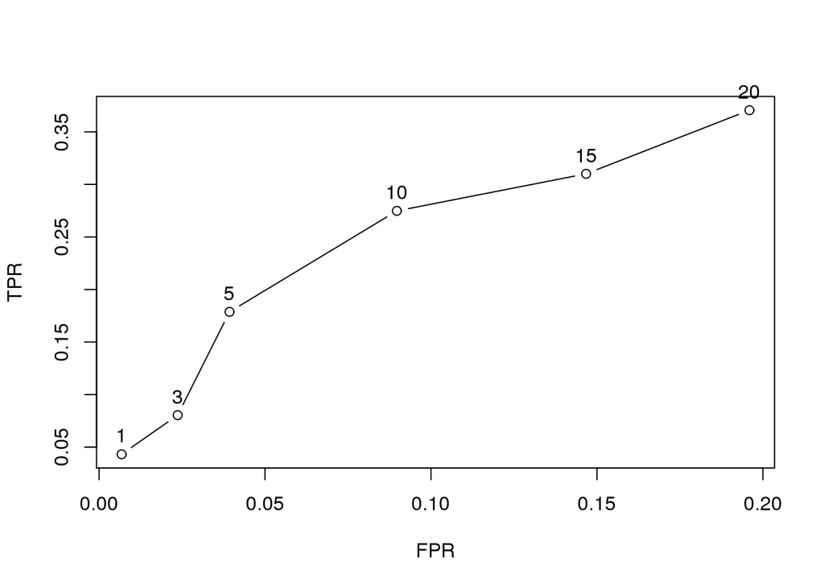

```r
## Plotting ROC curve and precision-recall plot.
plot(results, annotate=TRUE) #ROC, plots the true positive rate (TPR) against the false positive rate (FPR).
```

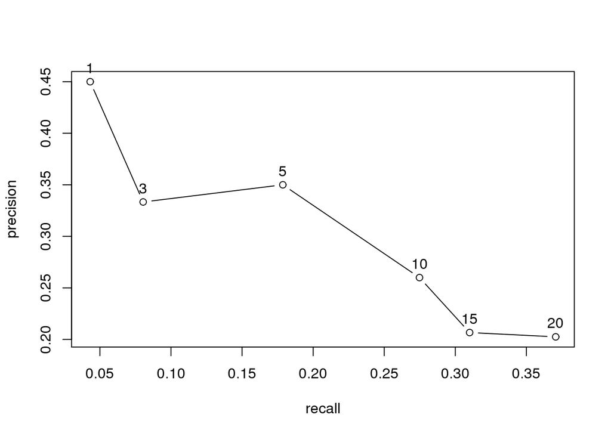

```r
plot(results, "prec/rec", annotate=TRUE) #precision-recall.
```

10 Use the evaluation scheme created above to compare the three recommender algorithms: random items, popular items, and user-based CF based recommendations. Plot the ROC curve and the precision-recall plot with the three methods on each plot. Discuss.

```r
## Comparing the three recommender algorithms.
scheme <- evaluationScheme(Jester5k[1:20], method="split", train = .75,
                           k=1, given=5, goodRating=3)
scheme
```

```
## Evaluation scheme with 5 items given
## Method: 'split' with 1 run(s).
## Training set proportion: 0.750
## Good ratings: >=3.000000
## Data set: 20 x 100 rating matrix of class 'realRatingMatrix' with 1580 ratings.
```

```r
algorithms <- list(
  "random items" = list(name="RANDOM", param=NULL),
  "popular items" = list(name="POPULAR", param=NULL),
  "user-based CF" = list(name="UBCF", param=list(method="Cosine",
        nn=50, minRating=5)))
results <- evaluate(scheme, algorithms, n=c(1, 3, 5, 10, 15, 20))
```

```
## RANDOM run
##   1  [0.004sec/0.014sec]
## POPULAR run
##   1  [0.008sec/0.008sec]
## UBCF run
##   1  [0.004sec/0.028sec]
```

```r
results
```

```
## List of evaluation results for 3 recommenders:
## Evaluation results for 1 runs using method 'RANDOM'.
## Evaluation results for 1 runs using method 'POPULAR'.
## Evaluation results for 1 runs using method 'UBCF'.
```

```r
names(results)
```

```
## [1] "random items"  "popular items" "user-based CF"
```

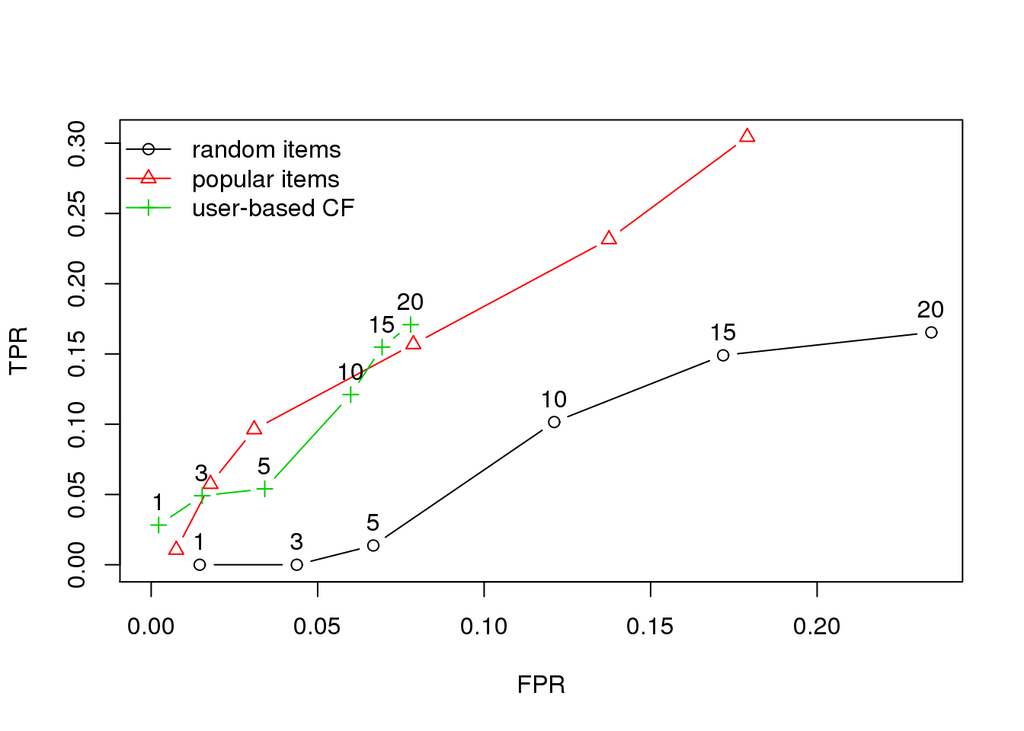

```r
plot(results, annotate=c(1,3), legend="topleft")
```

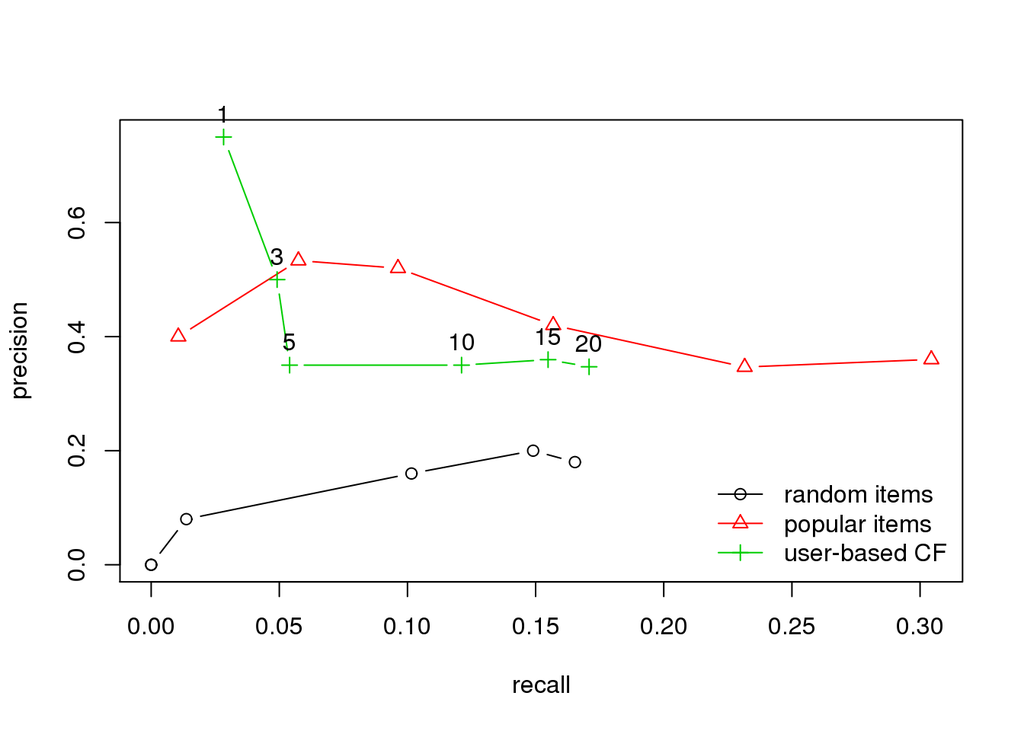

```r
plot(results, "prec/rec", annotate=3)
```

For this data set and the given evaluation scheme the user-based and popular item-based CF methods are better than all other methods.